# iAI_Notebook_Manual

**Manual for iPython Notebook**

By Prof. Seungchul Lee  
http://iai.postech.ac.kr/  
Industrial AI Lab at POSTECH

Source (example)

- Materials from linear algebra review by Prof. Zico Kolter from CMU
- online
  - http://www.cs.cmu.edu/~zkolter/course/linalg/
  - http://www.cs.cmu.edu/~jingx/docs/linearalgebra.pdf

```python
<br><br>
<font size = "6">
<b>Manual for iPython Notebook</b>
</font>

<br>
<div class=pull-right>
By Prof. Seungchul Lee<br>
http://iai.postech.ac.kr/<br>
Industrial AI Lab at POSTECH
</div>

<br>

<br>
Source

- Materials from linear algebra review by Prof. Zico Kolter from CMU
- online
    - http://www.cs.cmu.edu/~zkolter/course/linalg/
    - http://www.cs.cmu.edu/~jingx/docs/linearalgebra.pdf
```

**목차 만들때**

Table of Contents

```python
Table of Contents
<div id="toc"></div>
```

아랫 부분은 모든 ipython notebook의 가장 아래에 위치시키기. 아랫 부분을 실행시켜야 목차가 생성된다.

```python
%%javascript
$.getScript('https://kmahelona.github.io/ipython_notebook_goodies/ipython_notebook_toc.js')
```

# 1. Title (제목)

## 1.1. 큰제목 (Introduction / Conclusion 등)

논문제목은 # 1개, 큰제목은 ## 2개, 작은제목은 ### 3개 정도로 쓰면 됨

내용 작성

식은 Latex로 작성 $$\begin{bmatrix} \hat{u}_1 & \hat{u}_2 \end{bmatrix} = \begin{bmatrix} \hat{x}_1 & \hat{x}_2 \end{bmatrix} \begin{bmatrix} c_1 & c_2 \\ c_2 & c_4 \end{bmatrix} $$

```python
$$\begin{bmatrix} \hat{u}_1 & \hat{u}_2 \end{bmatrix} =
\begin{bmatrix} \hat{x}_1 & \hat{x}_2 \end{bmatrix}
\begin{bmatrix} c_1 & c_2 \\ c_2 & c_4 \end{bmatrix} $$

$$
\begin{align*}

\end{align*}
$$
```

# 2. 관련 자료 첨부 방법

## 2.1. 동영상 링크

관련 동영상은 유튜브 링크를 걸어서 첨부할 수 있다. 아래 코드를 복사해서 유튜브 주소 변경, width, height만 조절하면 됨

```python
%%html
<center><iframe src="https://www.youtube.com/embed/wfVg2lqqhaw"
width="560" height="315" frameborder="0" allowfullscreen></iframe></center>
```

**youtube time trim**

`?start=144&end=200`

```python
%%html
<center><iframe src="https://www.youtube.com/embed/wfVg2lqqhaw?start=40&end=60"
width="560" height="315" frameborder="0" allowfullscreen></iframe></center>
```

**youtube 끝나고 관련 동영상 추천하지 않기**

?rel=0

```python
%%html
<center><iframe src="https://www.youtube.com/embed/wfVg2lqqhaw?rel=0"
width="560" height="315" frameborder="0" allowfullscreen></iframe></center>
```

## 2.2. 이미지 첨부

모든 이미지는 image_files 폴더에 넣는다.

HTML Embedded (.html) 을 사용하면 html 파일에 그림파일이 내장되기 때문에 image_files 이 같이 따라 다닐 필요가 없다.

```python
<center><img src = "./image_files/05_eigvector.png" width = 300></center>
```

**Table**

테이블은 가능하면 사용하지 않는다. html로 전환했을때 특정 PC에서만 제대로 동작한다. 그림 두개를 동시에 capture해서 그림 하나로 삽입하도록.

- 논문에 넣을 이미지는 ipython notebook 동일 폴더 내에 따로 이미지파일 폴더 (현재 image_files로 설정)를 생성하고 그 폴더 안에 저장함
- 위의 코드를 복사해서 사용
- " " 큰따옴표 안의 'image_files'는 이미지가 들어있는 폴더이름으로 변경
- '05_eigenvector.png'는 첨부하고싶은 이미지의 '이미지파일이름.확장자'로 변경
- width나 height로 이미지 크기를 조절할 수 있음

```python
<table style="border-style: hidden; border-collapse: collapse;" width = "96%">
    <tr style="border-style: hidden; border-collapse: collapse;">
        <td width = 48% style="border-style: hidden; border-collapse: collapse;">
<img src = "./image_files/05_eigvector.png" width=300>
        </td>
        <td width = 48%>
<img src = "./image_files/05_eigvector.png" width=300>
        </td>
    </tr>
</table>
```

## 2.3. PDF 첨부

예시) iPCA: An Interactive System for PCA-based Visual Analytics [pdf]

- 내용 작성에 참고한 reference를 넣을 때
- (이미지와 동일) ipython notebook 동일 폴더 내에 따로 pdf보관폴더 (현재 reference_files 로 설정)를 생성하고 그 폴더 안에 저장함
- 위의 코드를 복사해서 사용
- " " 큰따옴표 안의 'reference_files'는 pdf 들어있는 폴더이름으로 변경
- 'An Interactive System for PCA-based Visual Analytics.pdf'는 첨부하고싶은 pdf파일의 '파일이름.pdf'로 변경
- <,> 사이에 '[pdf]'는 링크가 걸리는 텍스트

```python
<a href="./reference_files/An Interactive System for PCA-based Visual Analytics.pdf" target="_blank">[pdf]</a>
```

## 2.4. 데이터 다운 받기 설정

코드 실행을 위한 데이터를 드랍박스에 업로드한다. (연구실 드랍박스 계정 사용)

수업관련 자료 데이터는 아래 폴더에 넣어둔다.

- D:\Dropbox\01_POSTECH\05_iAI_teaching\iAI_data_archive\

1) 업로드 후 'Share' click

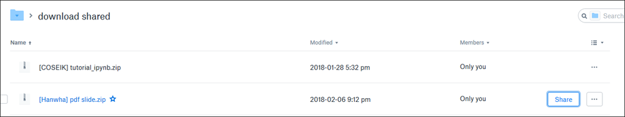

2) Copy link

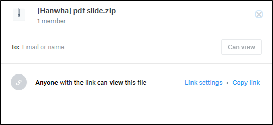

3) URL 변경

[figure not shown]

$\quad \;$가장 끝에 있는 숫자를 0에서 1로 바꾸어 준다. (파일 자동 다운로드 옵션)

$\quad \;$https://www.dropbox.com/s/67oqj301c8bsy1r/%5BHanwha%5D%20pdf%20slide.zip?dl=0

$\quad \;$https://www.dropbox.com/s/67oqj301c8bsy1r/%5BHanwha%5D%20pdf%20slide.zip?dl=1

4) 링크 ipython notebook 에서 설정

$\quad \;$[data downlaod](https://www.dropbox.com/s/67oqj301c8bsy1r/%5BHanwha%5D%20pdf%20slide.zip?dl=1)

## 2.5. 웹페이지 링크

예시) 대전 타슈 자전거 이용 데이터 시각화 - [data link](https://www.data.go.kr/)

- 해당 내용에 사용된 데이터나 참고한 웹페이지 링크
- 위의 코드 복사해서 사용
- [링크를 걸 글].(웹페이지주소) 중앙에 점(.)을 빼고 사용하면됨

```python
[data link](https://www.data.go.kr/)
```

[개통 2개월 밖에 안 된 SRT 객실에서 진동이 심하다는 민원이 속출하고 있다](http://www.huffingtonpost.kr/2017/02/06/story_n_14631014.html)

```python
<a href="http://www.huffingtonpost.kr/2017/02/06/story_n_14631014.html" target="_blank">
개통 2개월 밖에 안 된 SRT 객실에서 진동이 심하다는 민원이 속출하고 있다</a>
```

# 3. 수식

latex 참고시 유용한 싸이트

- https://en.wikibooks.org/wiki/LaTeX/Mathematics
- http://web.ift.uib.no/Teori/KURS/WRK/TeX/symALL.html

## 절대값이나, norm등 좌우로 막대기 세우고싶을때

$\lVert, \rVert$

$\lvert, \rvert$

```python
$\lVert, \rVert$

$\lvert, \rvert$
```

## theta쓰기

$\cos \theta$

```python
$\cos \theta$
```

## $x \in \mathbb{R}$ 같은거 할때

$\mathbb{R}$

```python
$\mathbb{R}$
```

## 합을표현할때

```python
$\prod\limits_{i=1}$
```

$\sum\limits_{i=1}$

```python
$\sum\limits_{i=1}$
```

## w가 아니라 omega 쓸때

$\omega$

```python
$\omega$
```

## \$ 모양 써서 수학기호를쓰는데 그사이에 글넣고싶을때

텍스트넣기

$$\text{ text here }$$

```python
텍스트넣기

$$\text{ text here }$$
```

## 수식을 줄맞춰서 예쁘게 쓸 필요가 있을때

수식 줄맞춤 $$ \begin{align*} x_1 & = 1 + 2\\ x_2 &= 2 + 4 + 2 + 4 \end{align*} $$

```python
수식 줄맞춤
$$
\begin{align*}
x_1 & = 1 + 2\\
x_2 &= 2 + 4 + 2 + 4
\end{align*}
$$
```

## < >

$\langle x1, x2 \rangle$

```python
$\langle x1, x2 \rangle$
```

## 글자의 크기에따라 괄호사이즈를 다르게 할 필요가 있을때 (기본적으로 이괄호를 쓰는걸로)

괄호 사이즈 adjust

$\left( \frac{1}{2} \right)$

$\left(1 \right)$

\left \right 을 꼭 사용하도록.

```python
괄호 사이즈 adjust

$\left( \frac{1}{2} \right)$

$\left(1 \right)$
```

## \hat{e_1} 아님

hat씌우는거 통일

$\hat{e}_1$

```python
hat씌우는거 통일

$\hat{e}_1$
```

표만들기

| items | 1 | 2 | 3 | 4 | 5 | 6 |
| --- | --- | --- | --- | --- | --- | --- |
| weights | 10 | 9 | 4 | 2 | 1 | 20 |
| values | 175 | 90 | 20 | 50 | 10 | 200 |

```python
표만들기

|items|1|2|3|4|5|6
|:-:|:-:|:-:|:-:|:-:|:-:|:-:
|weights|10|9|4|2|1|20
|values|175|90|20|50|10|200
```

## 행렬만들때

행렬

$$\begin{bmatrix} 1 & \cdots & 2\\ \vdots & \ddots & \vdots \end{bmatrix}$$

```python
행렬

$$\begin{bmatrix}
1 & \cdots & 2\\
\vdots & \ddots & \vdots
\end{bmatrix}$$
```

## 그림, table 등 넣을때

```python
<br>
<center><img src = "./경로/파일명" width = 500></center>
<br>
```

그림 table , align 등등 나란히 넣기

테이블 만들기

$$ \begin{bmatrix} \cos(\theta)\\ \sin(\theta) \end{bmatrix}= R(\theta) \begin{bmatrix} 1\\ 0 \end{bmatrix}\\ $$

$$ \begin{bmatrix} \cos(\theta)\\ \sin(\theta) \end{bmatrix}= R(\theta) \begin{bmatrix} 1\\ 0 \end{bmatrix}\\ $$

| $$ \begin{bmatrix} \cos(\theta)\\ \sin(\theta) \end{bmatrix}= R(\theta) \begin{bmatrix} 1\\ 0 \end{bmatrix}\\ $$ | $$ \begin{bmatrix} \cos(\theta)\\ \sin(\theta) \end{bmatrix}= R(\theta) \begin{bmatrix} 1\\ 0 \end{bmatrix}\\ $$ | $$ \begin{bmatrix} \cos(\theta)\\ \sin(\theta) \end{bmatrix}= R(\theta) \begin{bmatrix} 1\\ 0 \end{bmatrix}\\ $$ |
| --- | --- | --- |

```python
그림 table , align 등등 나란히 넣기

테이블 만들기

<table style="border-style: hidden; border-collapse: collapse;" width = "96%">
    <tr style="border-style: hidden; border-collapse: collapse;">
        <td width = 48% style="border-style: hidden; border-collapse: collapse;">
          $$
            \begin{bmatrix}
            \cos(\theta)\\
            \sin(\theta)
            \end{bmatrix}=
            R(\theta)
            \begin{bmatrix}
            1\\
            0
            \end{bmatrix}\\
            $$
        </td>
        <td width = 48%>
            $$
            \begin{bmatrix}
            \cos(\theta)\\
            \sin(\theta)
            \end{bmatrix}=
            R(\theta)
            \begin{bmatrix}
            1\\
            0
            \end{bmatrix}\\
            $$
        </td>
    </tr>
</table>
```

## 기호

therefore

$\therefore$

```python
therefore

$\therefore$
```

## 수식 안에서 띄워쓰고싶을때

띄어쓰기

$$x y$$$$x \, y $$$$x \; y $$$$x \space y $$$$x \quad y $$$$x \qquad y $$

```python
띄어쓰기

$$x y$$
$$x \, y $$
$$x \; y $$
$$x \space y $$
$$x \quad y $$
$$x \qquad y $$
```

## case 만들고싶을때

$$\begin{cases} \text{positive}\\ 0\\ \text{negative} \end{cases}$$

```python
$$\begin{cases}
\text{positive}\\
0\\
\text{negative}
\end{cases}$$
```

## 글자크기 바꿀때

```python
글자크기

\Huge

\huge

\LARGE

\Large

\large

\normalsize (default)

\small

\footnotesize

\scriptsize

\tiny
```

# 4. HTML Converting

[figure not shown]

- ipynb 파일과 같은 위치에 있어야 relative path가 동작한다.
- github 에는 html 파일을 올리고, 필요하다면 관련 image_files, reference_files, data_files 폴더까지 함께 업로드해야 한다.
- github 는 연구실 계정으로 접속
- html 로 전환하기 전에 아래 과정을 통해 셀의 번호가 [1], [2], $\cdots$ 로 순차적으로 올라가는 것을 확인한다.

$\quad \;$Kernel $\rightarrow$ Restart $\rightarrow$ Clear all outputs & restart $\rightarrow$ run all

[figure not shown]

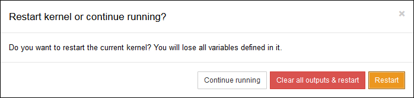

[figure not shown]

- 앞으로는 html 전환시 이미지가 임베딩되는 아래 처럼 사용하도록.
  - extension 을 설치해야 합니다.

[figure not shown]

# 5. Hide Codes

아래 코드를 실행하면 코드가 보이지 않음

```python
from IPython.display import HTML

HTML("""<script>
  $( document ).ready(function(){
    code_shown=false;
    $('div.input').hide()
  });
</script>""")
```

```python
%%javascript
$.getScript('https://kmahelona.github.io/ipython_notebook_goodies/ipython_notebook_toc.js')
```